# @AdelphiResearch tweets

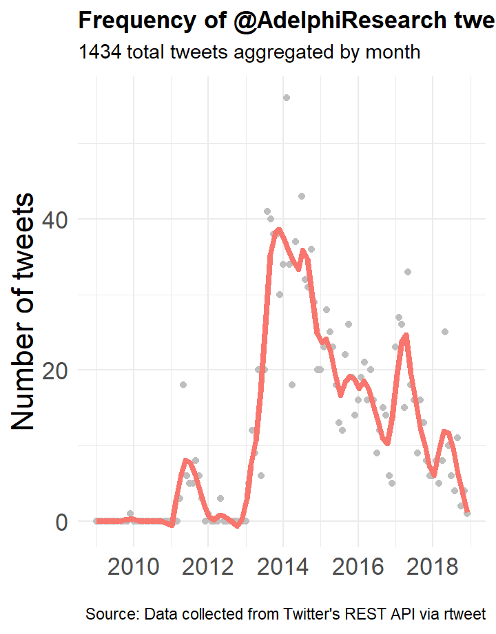

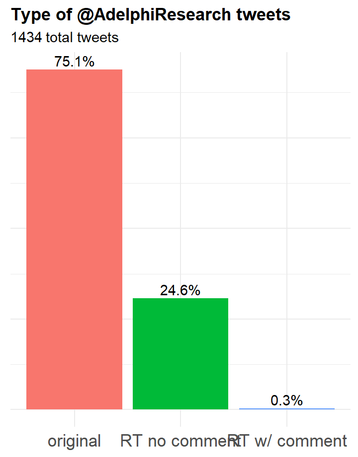

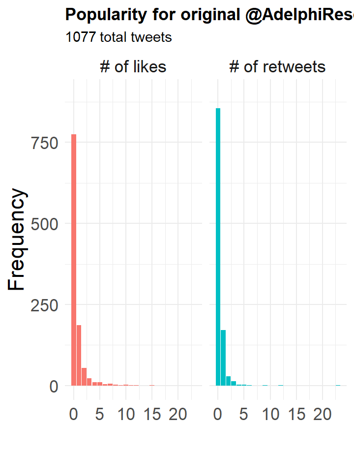

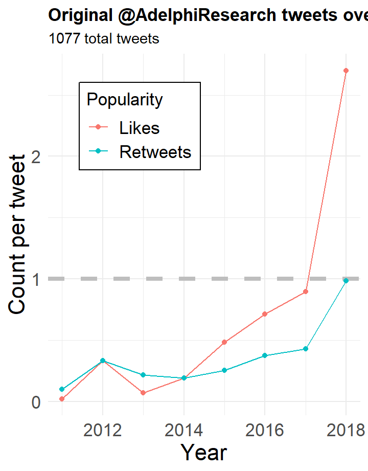

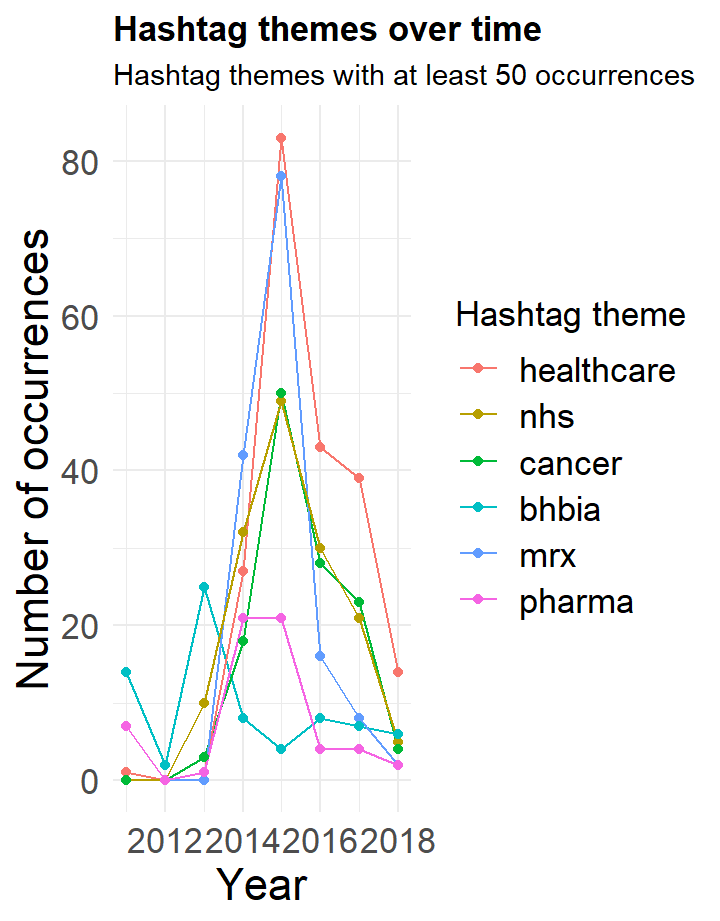

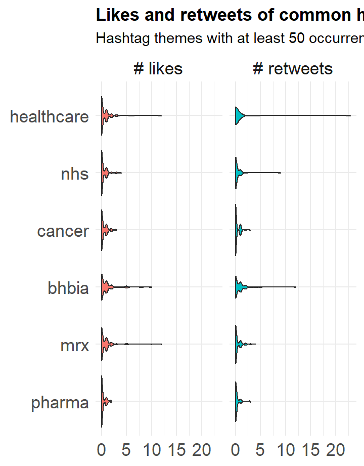

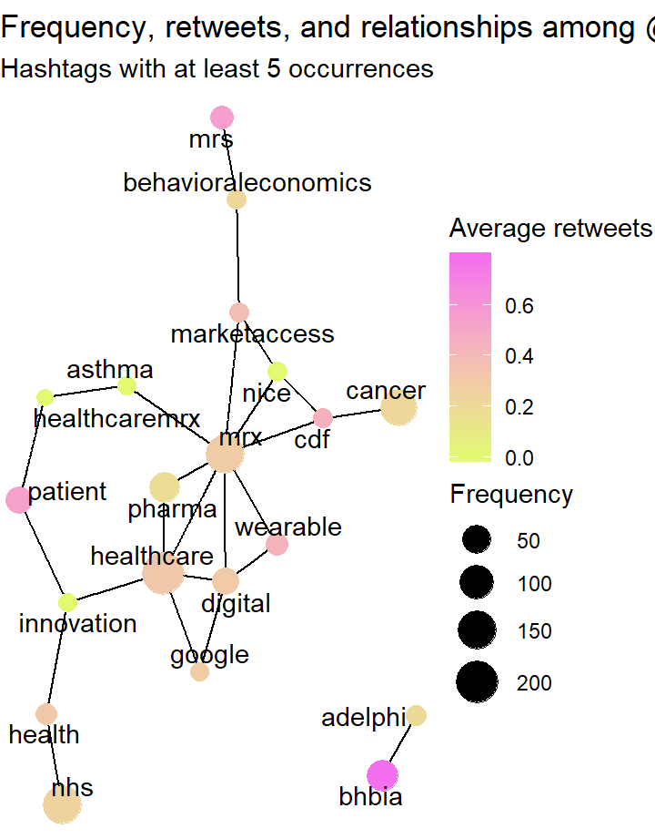

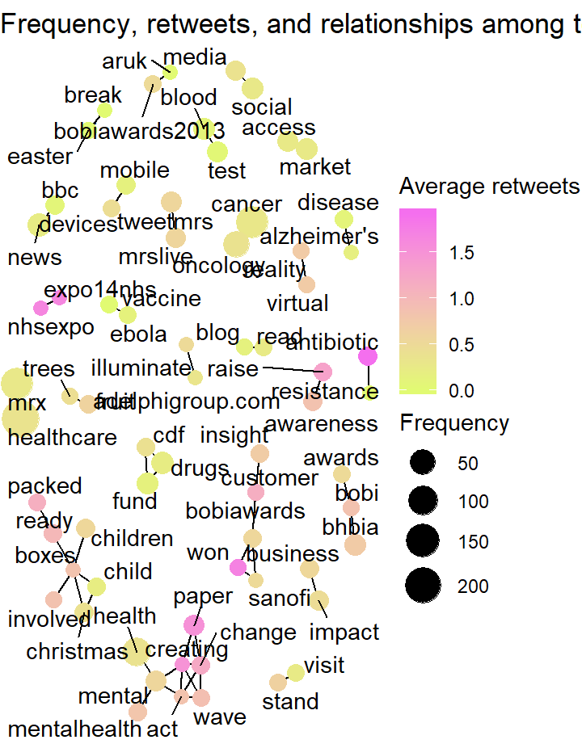

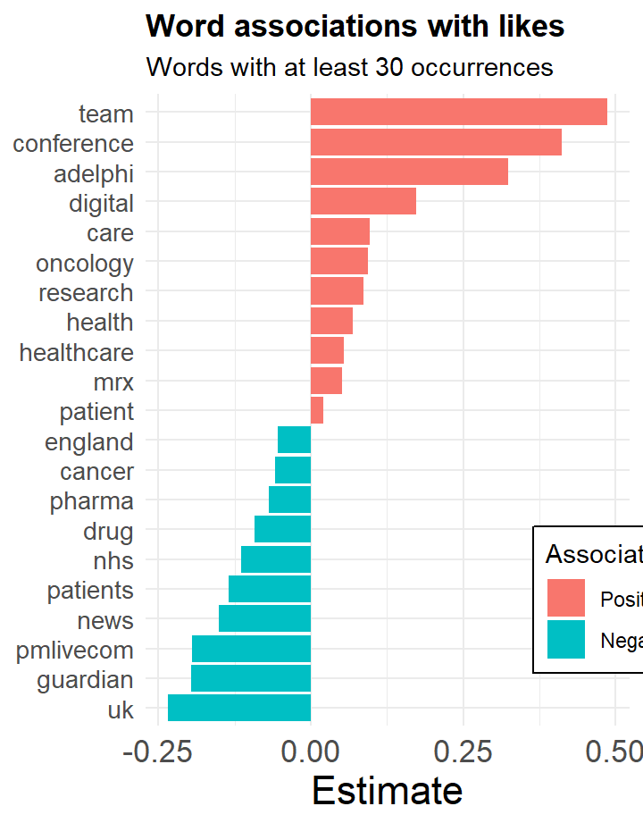

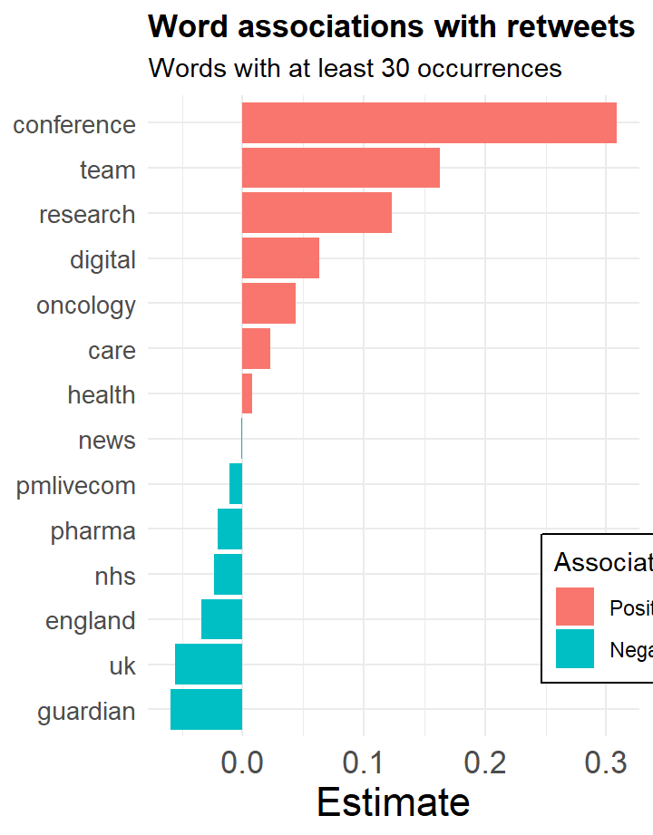

# Introduction

### Example tweet

> We are feeling festive!! The Christmas boxes for Operation Christmas child are packed and ready to go. We packed 22 this year and they will go to Children in need around the world. [#Samaritanspurse](https://twitter.com/hashtag/Samaritanspurse?src=hash&ref_src=twsrc%5Etfw) [#christmasboxes](https://twitter.com/hashtag/christmasboxes?src=hash&ref_src=twsrc%5Etfw) [pic.twitter.com/IE2nAQHeuO](https://t.co/IE2nAQHeuO)

> — Adelphi Research (@AdelphiResearch) [November 19, 2018](https://twitter.com/AdelphiResearch/status/1064553799417769989?ref_src=twsrc%5Etfw)

#### Shiny Apps

- [Tweet look-up](https://spileggi.shinyapps.io/tweet_lookup/)
- [Term network analysis](https://spileggi.shinyapps.io/tweet_network/)

### Motivation

- Learn about Adelphi Research’s values and initiatives.
- Provide Adelphi Research with insights regarding tweet themes and popularity.
- Explore R packages
  - First time: `rtweet`, `scales`, `tidytext`, `widyr`, `ggraph`, `igraph`, `corrr`, `glmnet`
  - Continued learning: `tidyverse`, `forcats`, `skimr`, `lubridate`, `broom`, `flexdashboard`, `DT`
- Presentation checklist:
  - focuses on market research
  - innovative
  - proud of

### Things I learned

#### Acronyms

- BHBIA = British Healthcare Business Intelligence Association
  - BOBI = Best of Business Intelligence
- NHS = National Health Service (UK)
- MRS = Market Research Society (UK)
- NICE = National Institute for Health and Care Excellence (UK)
- CDF = Cancer Drugs Fund (England)
- #mrx = market research

#### Interests

- Probably a lot of market research in cancer treatments.
- Other areas?

#### Miscellaneous

- Adelphi Research wrote an [NHS Nuggets blog](http://nhsnuggets.blogspot.com/) from 2011 to 2015
- In 2016 & 2017, participated in a campaign to [plant fruit trees](https://twitter.com/search?q=%40AdelphiResearch%20fruit%20trees&src=typd) in Africa
- [Adelphi illuminate innovation lab](http://www.adelphiresearchglobal.com/wish-you-could-be-a-fly-on-the-wall-at-a-doctors-office/) is testing market research + virtual reality
- Adelphi’s pro-bono work in [Creating a wave of change in the Mental Health Act](http://www.pharmatimes.com/web_exclusives/creating_a_wave_of_change_in_the_mental_health_act_1241509)
- The Guardian is Bristish daily newspaper.
- Adelphi operates independently from Omnicom Group?

# Tweet overview

### Tweets over time

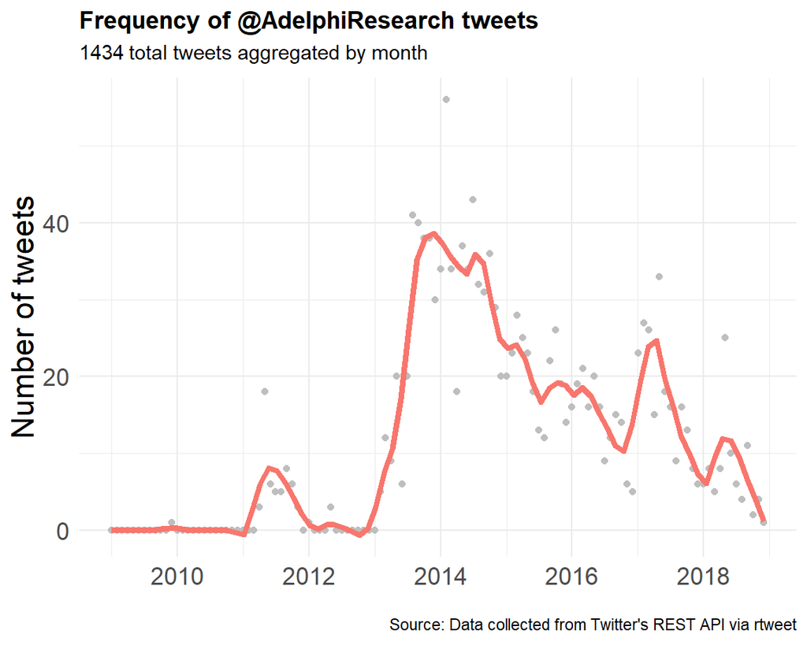

- 1434 tweets
- all originate from Bollington, Cheshire
- tweets begin at 2009-12-21 15:32:27, end at 2018-12-10 10:33:08
- original data set has 88 variables
- created an additional 11 variables for analysis

### Tweet type

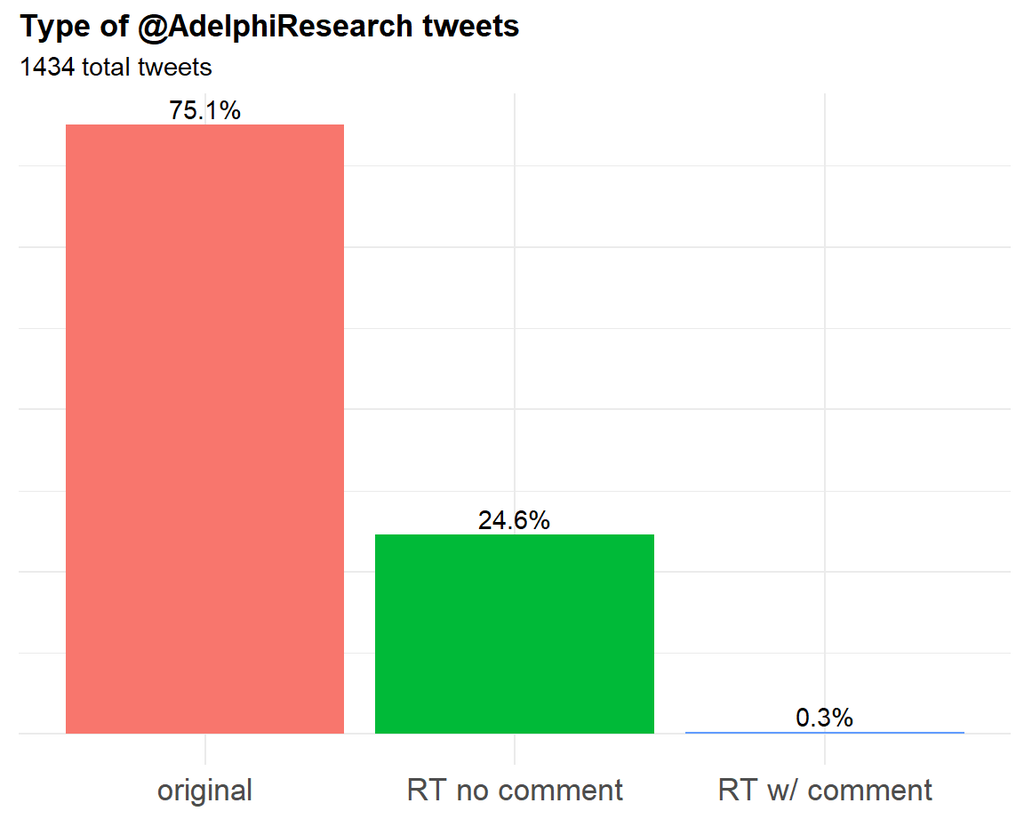

#### **Original tweet**

[figure not shown]

#### **RT no comment**

[figure not shown]

#### **RT w/ comment**

[figure not shown]

### Likes and retweets

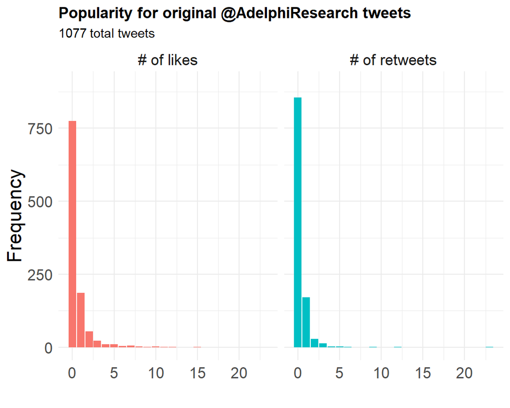

[Most retweeted original tweet](https://twitter.com/search?f=tweets&q=%40AdelphiResearch%20New%20drug%20kills%20antibiotic-resistant%20bacteria%20&src=typd)

[Most liked original tweet](https://twitter.com/search?q=%40AdelphiResearch%20wearing%20yellow&src=typd)

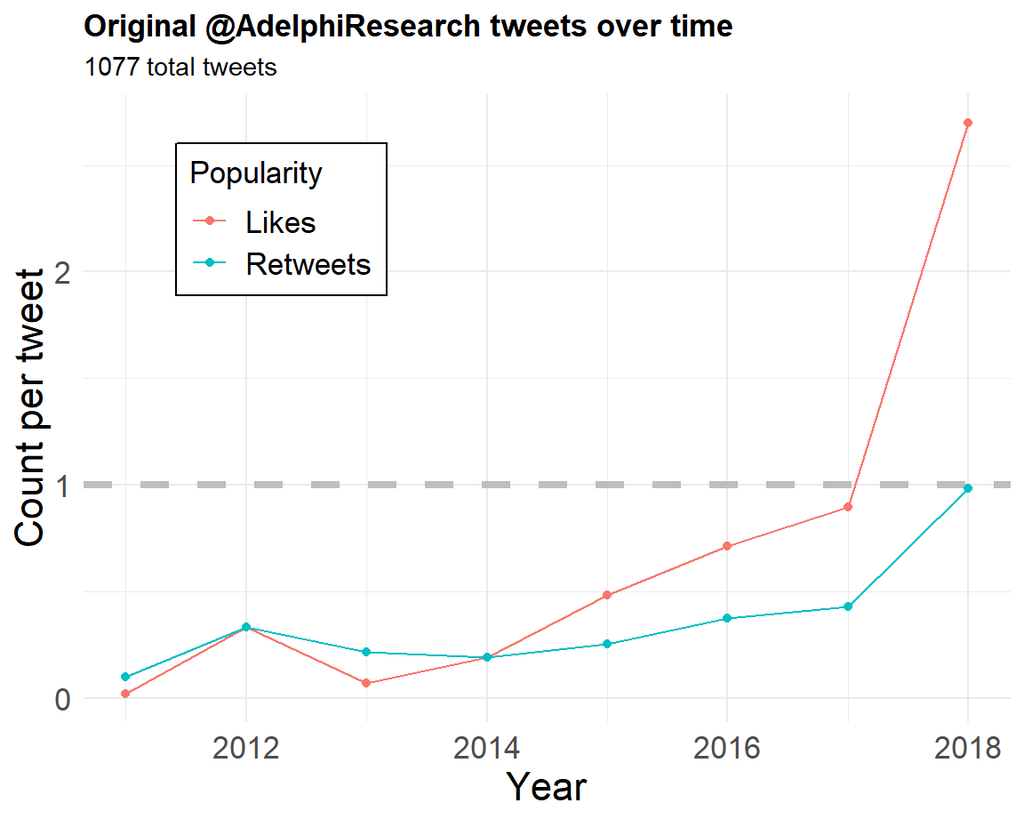

# Hashtags

### Common hashtag themes

|  | Hashtag theme | Frequency |
| --- | --- | --- |
| 1 | healthcare | 208 |
| 2 | nhs | 147 |
| 3 | mrx | 146 |
| 4 | cancer | 126 |
| 5 | bhbia | 74 |
| 6 | pharma | 60 |
| 7 | patient | 37 |
| 8 | digital | 34 |
| 9 | mrs | 20 |
| 10 | wearable | 16 |

[output cut: 211 more lines]

#### 1077 tweets:

- 38.9% have 0 hashtags
- 61.1% have 1 to 6 hashtags

#### 1266 hashtags used:

- 321 unique hashtags
- 221 unique hashtag themes
  - bhbia, bobi -> bhbia
  - cancer, oncology, chemo -> cancer
  - mrx, marketresearch -> mrx

### Hashtag theme trends

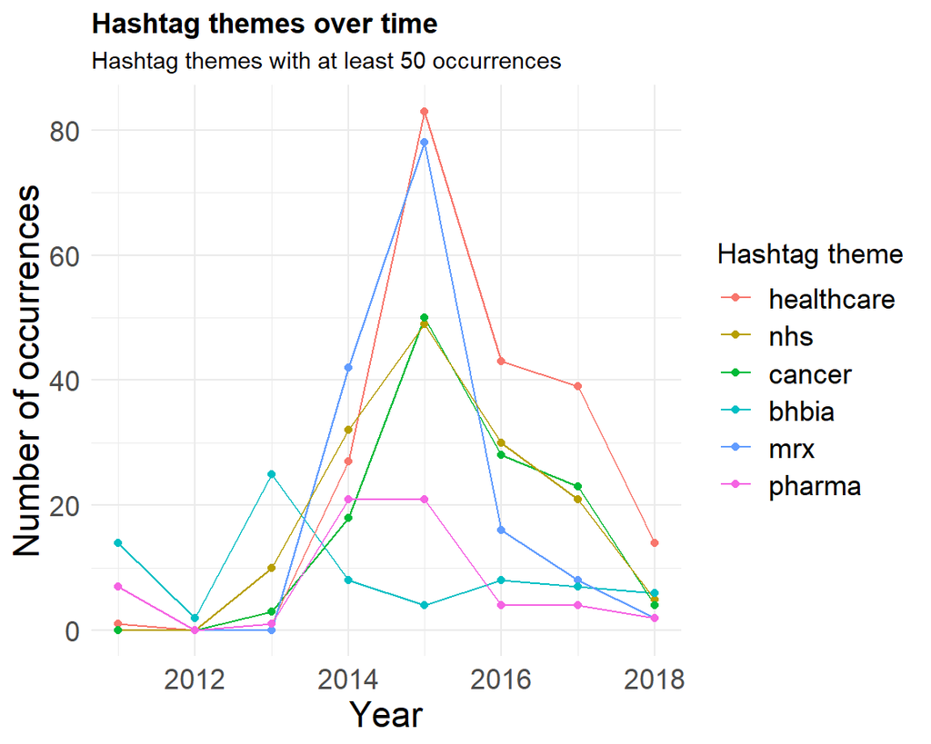

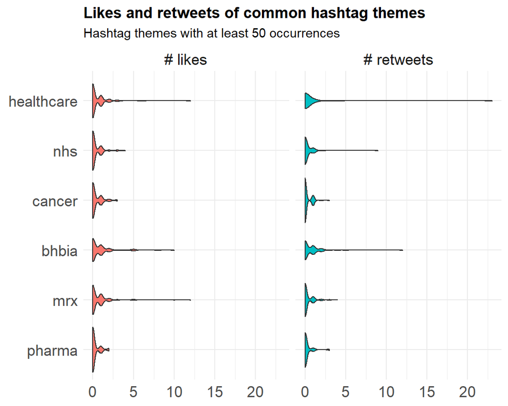

### Hashtag network

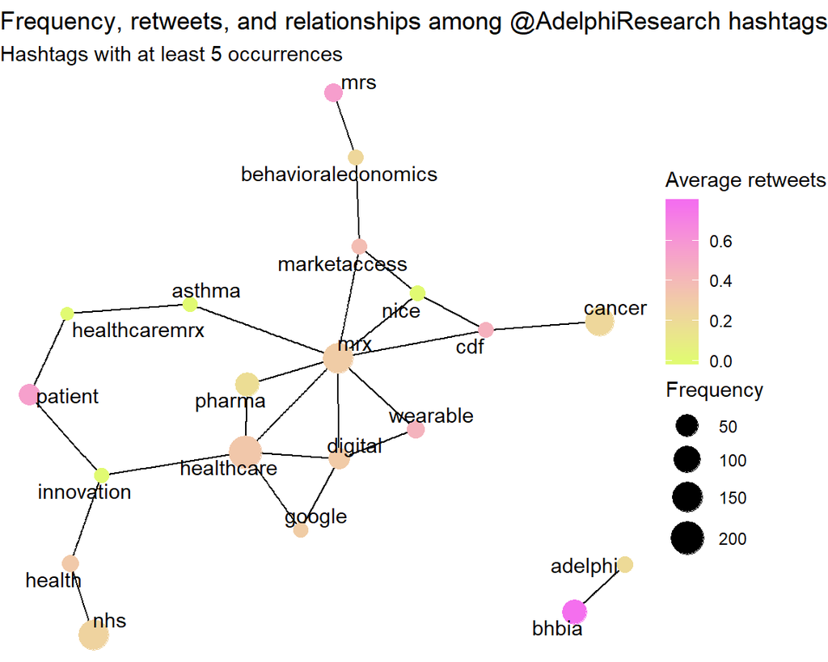

# Tweet text

### Text network

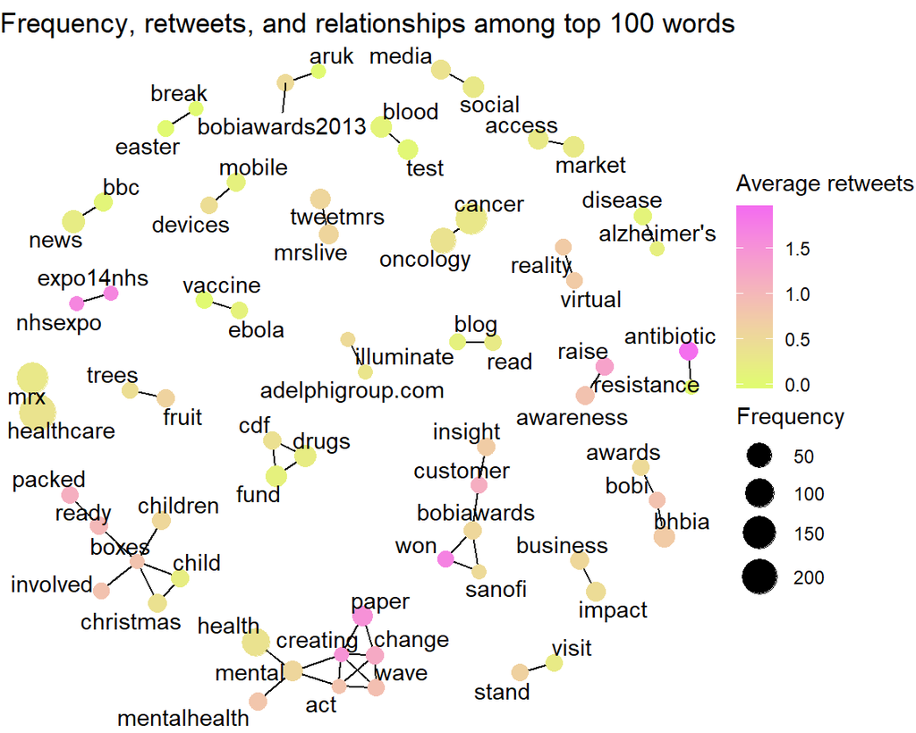

### LASSO model

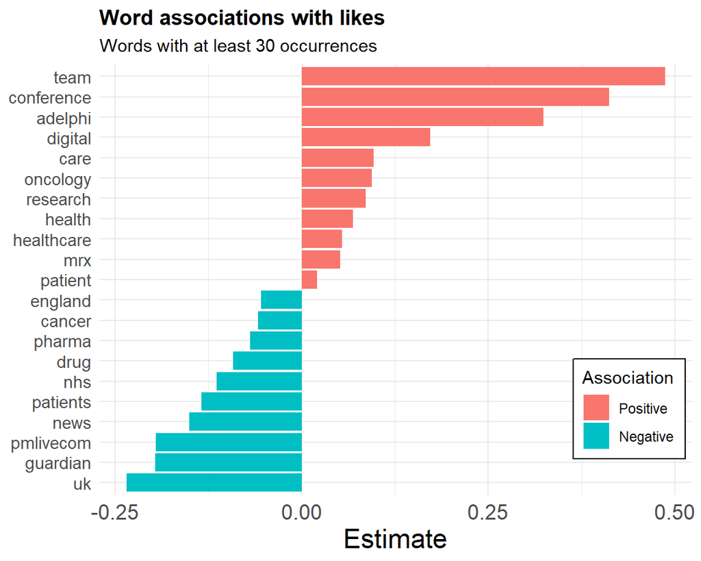

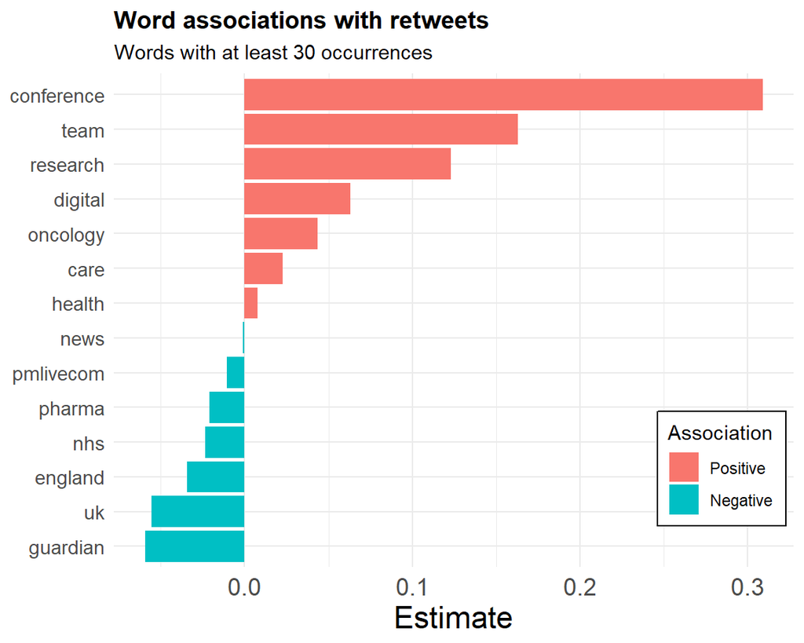

# Summary

### Key findings

#### Overall

- The frequency of tweets is descreasing in 2018, but like-to-tweet and retweet-to-tweet ratios are increasing.

#### Tweet text

- *Network analysis*: words that got together and tend to get more likes/retweets
  - won, BHBIA, BOBI awards
  - creating, change, wave ([this](https://twitter.com/AdelphiResearch/status/996412063907016704))
  - ready, boxes, involved, children
- *Model analysis*: words associated with retweets/likes
  - positively -> conference, team
  - negatively -> UK, guardian

### Future work

- Incorporate other variables in a unified model.
- Consider elastic net model for correlated variables.
- Examine network of retweet-ers.
- Sentiment analysis of tweet text.
- Build app to predict number retweets/likes based on input words or hashtags.

### Applications

- Text analysis of open-ended survey data.
- Text analysis of open-ended claims data.
- Reproducible reports for tight deadlines.
- Social media in market research.

### Acknowledgements

- [@drob’s #tidytuesday screencast on analyzing Medium posts](https://twitter.com/drob/status/1069954125020958720)
- [@EmilyRiederer’s suggestion to do a presentation using flexdashboard](https://twitter.com/EmilyRiederer/status/1073001289339027456)